# Completing the AI Projectile Weapon

Like I mentioned in the previous lesson, the weapons system is probably the most complicated part of our demo.

Previously, we implemented a bare minimum projectile weapon, but we need to control it somehow.

In this lesson, we’ll look at AI weapon controllers and how they manage their assigned weapons.

We want the AI to:

1. Target a room in the player’s ship with each of its weapons.
2. Wait for the weapon to fire.
3. Rearm the weapon to fire again, changing the target room.

We’ll create a weapon controller that’ll do all of the above, following these steps:

1. We start by requesting a random target position from the player ship.
2. The controller passes the targeting information to the weapon.
3. Once the weapon charges up, it fires the projectile towards the target position. At the moment it fires, the weapon also emits the `fired` signal.
4. The `fired` signal is hooked up to the parent controller which starts the process over.

This separation between weapons and their controller allows both players and AI to use any weapon.

In this lesson, we’ll make preparations that allow us to transfer the projectile from one viewport to the next.

The next lesson will cover the implementation details.

## Updating the projectile weapon

Before moving to the controllers, we need to update our `WeaponProjectile` class.

We need a way to signal when the weapon fires so that the controller knows when to request a new target.

We also need to store the target position and setup the collision layer for the projectile.

We’ll use this information practically in the next lesson when we make the projectile go from one viewport to the other.

Here, we’re preparing the terrain.

Open `res://TacticalSpaceCombat/Ship/Weapons/WeaponProjectile.gd` and add the following signal at the top:

```
## Emitted every time the weapon fires a projectile.
signal fired
```

We also need to define these variables:

```
## This gets updated every time the controller requests targeting information
## from the opponent ship.
var target_position := Vector2.INF

## When the AI shoots, we set this to the player ship's physics layer so that
## the projectile knows to interact with it. And vice-versa for the player.
var _physics_layer := -1


func setup(physics_layer: int) -> void:
    _physics_layer = physics_layer
```

Now, we need to update `fire()` to emit the `fired` signal at the end of the function:

```
func fire() -> void:
    # ...
    emit_signal("fired")
```

This signal tells the controller that the weapon is ready to update its targeting information.

And finally, we update the firing conditions to account for targeting information. Replace the `can_fire()` function with:

```
func can_fire() -> bool:
    return not is_charging and target_position != Vector2.INF
```

### Editor warnings to avoid invalid design

The way we’ll construct the ship is by having a `Controller -> Weapon` relationship.

We avoid constructing a controller scene having the weapon child node because we have custom *Inspector* properties on the weapon node. We’d have to turn on *Editable Children* otherwise, and this isn’t a very stable feature in Godot.

We avoid this problem by warning the designer about improper use of nodes.

To implement the custom warning system that Godot uses, we overwrite the `_get_configuration_warning()` function. But for this to work, we have to make this a script that runs in the editor:

```
tool
# extends Weapon
# ...
```

Add the `_get_configuration_warning()` function to the script:

```
## By overwriting this function, we can tell Godot to issue a warning with
## showing the returned string. If the return value is an empty string, Godot
## doesn't show any warnings.
func _get_configuration_warning() -> String:
    var parent := get_parent()
    var is_verified := parent != null and parent is ControllerAIProjectile
    return "" if is_verified else "WeaponProjectile needs to be a parent of ControllerAIProjectile"
```

You will see the configuration warning below after we define the ControllerAIProjectile class.

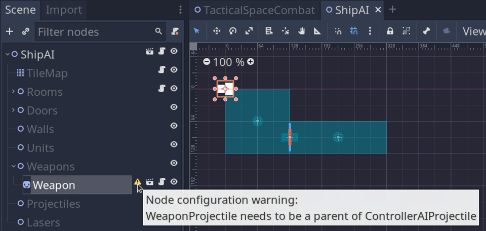

## Weapon controllers

We’ll now create a controller which we’ll have as a parent node for weapons.

For the AI, they request and update the targeting information for the weapons. To keep it interesting, we’ll add a bit of variation to the firing target using randomness.

For the player, controllers listen to the player’s input.

Like for weapons, we can use class inheritance to share functionality between the AI and the player.

### The controller base class

Let’s start with a base class.

Create a new script at `res://TacticalSpaceCombat/Ship/Weapons/Controller.gd`.

This is a base class that’ll contain all shared functionality between controllers:

```
class_name Controller
extends Node2D

## Every time the weapon fires, we emit the `targeting` signal.
signal targeting(msg)

## List of all weapon types. Currently, we only have projectile-based weapons,
## but we'll add lasers in another lesson.
enum Type {PROJECTILE}

## This is why we used the generic `Weapon` name for both projectile and laser
## specializations. We reference them with the same name.
##
## This is also the parent class of scripts that will run in the editor so we
## make sure to check for that.
onready var weapon: Weapon = null if Engine.editor_hint else $Weapon

func _on_Ship_targeted(msg: Dictionary) -> void:
    match msg:
        # The `..` syntax means "match anything" inside dictionaries and arrays.
        #
        # Here, the pattern matches any dictionary with at least a key named "type"
        # with a value of `Type.PROJECTILE`.
        {"type": Type.PROJECTILE, ..}:
            # A ship can have more than one weapon of each type. To distinguish
            # between them we use the `Controller` index position in the scene
            # tree.
            if msg.index == get_index():
                weapon.target_position = msg.target_position


func _get_configuration_warning() -> String:
    return "" if has_node("Weapon") else "%s needs a Weapon child" % name
```

With this parent class implemented, we need to specialize in handling the projectile weapon.

### The AI projectile controller

Add a new script file at `res://TacticalSpaceCombat/Ship/Weapons/ControllerAIProjectile.gd` with the following content:

```
## We make it a `tool` script to run in the editor to show a warning, like
## we did for `WeaponProjectile`. *Note* that the `tool` keyword is used in the
## sub-class.
tool
class_name ControllerAIProjectile
extends Controller


## Since this is the AI, we initiate weapon targeting in the `_ready()`
## function.
##
## We also connect the `fired` signal to `emit_signal()` to request a new
## target every time the weapon fires. This completes the cycle:
## `targeting -> fired -> targeting`.
func _ready() -> void:
    # We only run the `_ready()` function if we're not in the editor.
    if Engine.editor_hint:
        return

    # Initialize the AI weapon for interaction with the player ship.
    weapon.setup(Global.Layers.SHIPPLAYER)

    var msg := {"index": get_index()}
    weapon.connect("fired", self, "emit_signal", ["targeting", msg])

    # We wait one frame to let the engine finish inintializing everything before
    # emitting the `targeting` signal.
    yield(get_tree(), "idle_frame")
    emit_signal("targeting", msg)
```

We register the script as a new type, `ControllerAIProjectile`, to later check for controller types to set up the signal connections at the start of the game.

We don’t attach the script with any nodes here, because all registered classes with `class_name` can be added to the scene tree from the *Create New Node* panel. We’ll be using that method for the `Controller*` type nodes.

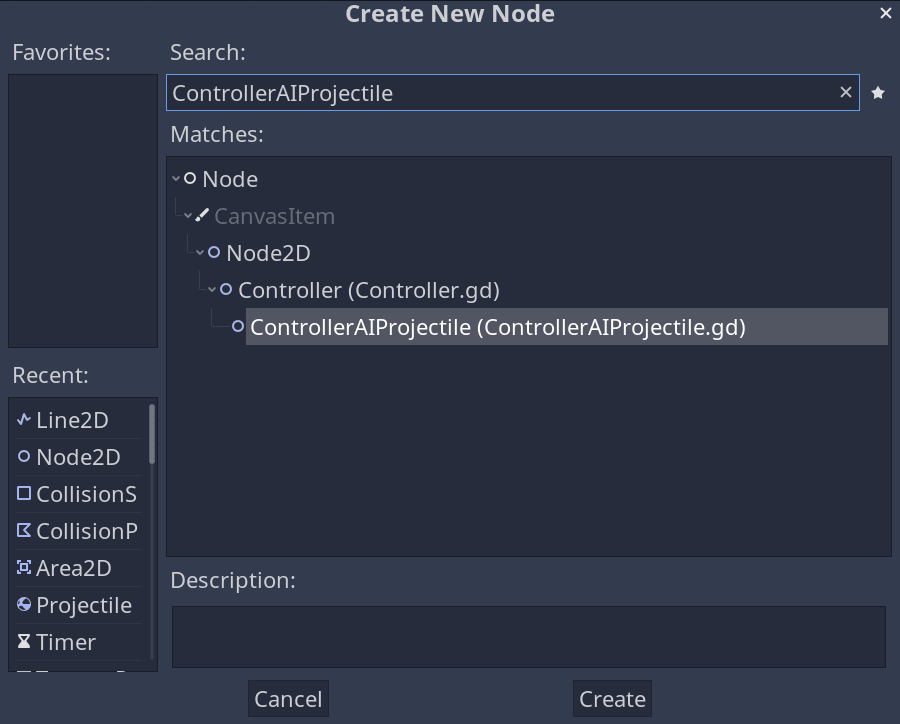

## Requesting the target

We have one more script to add to our demo.

*ControllerAIProjectile* requests a target via the `targeting` signal, but we haven’t implemented a function to handle it yet. We’ll do it now.

Open the *ShipTemplate* scene and add a new script to the *Rooms* node with the following content:

```
extends Node2D

## We send back to the `Controller` a message with target information via
## this signal.
signal targeted(msg)

## To keep it interesting we'll pick random targets using this random number generator.
var _rng := RandomNumberGenerator.new()
var _rooms_count := 0


func _ready() -> void:
    _rng.randomize()
    _rooms_count = get_child_count()


func _on_Controller_targeting(msg: Dictionary) -> void:
    # Get a random room index.
    var random_index := _rng.randi_range(0, _rooms_count - 1)
    var room: Room = get_child(random_index)

    # Add extra `type` and `target_position` keys with the requested information.
    # We use `msg.type` in the `match` statement back in the
    # `Controller._on_Ship_targeted()` function to distinguish between weapon
    # update messages.
    msg.type = Controller.Type.PROJECTILE
    msg.target_position = room.position
    emit_signal("targeted", msg)
```

We randomly select a room and attach this information to the dictionary. We then send it back when emitting the `targeted` signal.

Since we’re here, open `res://TacticalSpaceCombat/Ship/ShipTemplate.gd` and add a reference to the *Weapons* node:

```
onready var weapons: Node2D = $Weapons
```

We’ll need it for accessing the controller nodes in the next part.

## Connecting the signals

Up to this point, we added functionality in multiple places. To complete the implementation, we need to make the different parts communicate with each other.

We do this from `TacticalSpaceCombat.gd`, the script responsible for initializing and managing our game’s state.

```
# Reference to the AI ship that lives under the `Viewport` node.
onready var ship_ai: Node2D = $ViewportContainer/Viewport/ShipAI


func _ready_weapons_ai() -> void:
    for controller in ship_ai.weapons.get_children():
        if controller is ControllerAIProjectile:
            # We request new target positions via the controller `targeting` signal.
            controller.connect("targeting", ship_player.rooms, "_on_Controller_targeting")
            # We update the requested target position via the rooms' `targeted` signal.
            ship_player.rooms.connect("targeted", controller, "_on_Ship_targeted")
```

Now, we complete the script update by adding it to the `_ready()` function:

```
func _ready() -> void:
    #...
    _ready_weapons_ai()
```

## Constructing the controller-weapon hierarchy

In the previous lesson, we added a *Weapon* node under *Weapons* as a test. In this lesson, we implemented a controller-weapon system and need to integrate the new `ControllerAIProjectile` node into the *ShipAI* scene.

Open the *ShipAI* scene and update it as follows:

- Under the *Weapons* node, add a node of type `ControllerAIProjectile`. Find it in the *Create New Node* panel.
- Make the *Weapon* a child of it.

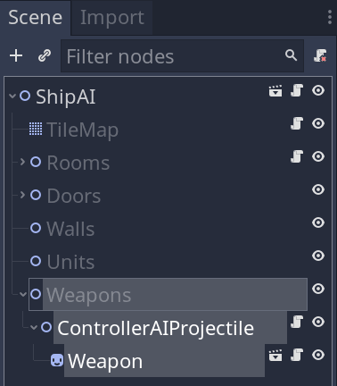

## Conclusion

In this lesson, we updated the AI controller-projectile weapons system to prepare it to shoot at specific rooms.

If you run the game now, nothing changed.

To test our work, I invite you to go to the `res://TacticalSpaceCombat/Ship/Weapons/Controller.gd` script and add a temporary print statement at the end of the `_on_Ship_targeted()` function:

```
func _on_Ship_targeted(msg: Dictionary) -> void:
    # ...
                # weapon.target_position = msg.target_position
                print("New `target_position` requested: ", msg.target_position)
```

Now, if you run the game, you should see an output like this:

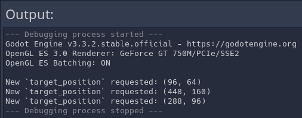

The `print()` function gets called every time the weapon fires with new targeting information from the opponent ship *Rooms* node.

In this lesson, we requested new targets via signals every time the projectile weapon fires.

This paves the way to the laser-based weapons because they’ll build upon the same base.

Now, we’re ready to cover moving projectiles between viewports in the next lesson.

## Code reference

`res://TacticalSpaceCombat/Ship/ShipTemplate.gd`:

```
tool
class_name ShipTemplate
extends Node2D

var _slots := {}

onready var scene_tree: SceneTree = get_tree()
onready var tilemap: TileMap = $TileMap
onready var rooms: Node2D = $Rooms
onready var doors: Node2D = $Doors
onready var units: Node2D = $Units
onready var weapons: Node2D = $Weapons


func _ready() -> void:
    call("_ready_editor_hint" if Engine.editor_hint else "_ready_not_editor_hint")


func _ready_editor_hint() -> void:
    for room in rooms.get_children():
        room.setup(tilemap)


func _ready_not_editor_hint() -> void:
    for unit in units.get_children():
        for door in doors.get_children():
            door.connect("opened", unit, "set_is_walking", [true])

        var position_map := tilemap.world_to_map(unit.path_follow.position)
        _slots[position_map] = unit

    for room in rooms.get_children():
        room.setup(tilemap)
        for point in room:
            tilemap.set_cellv(point, 0)
    tilemap.setup(rooms, doors)


func _unhandled_input(event: InputEvent) -> void:
    if not event.is_action_pressed("right_click"):
        return

    for unit in scene_tree.get_nodes_in_group("selected-unit"):
        var point1: Vector2 = tilemap.world_to_map(unit.path_follow.position)
        for room in scene_tree.get_nodes_in_group("selected-room"):
            if not room.owner.is_in_group("player"):
                break

            var point2: Vector2 = room.get_slot(_slots, unit)
            if is_inf(point2.x):
                break

            var path: Curve2D = tilemap.find_path(point1, point2)
            Utils.erase_value(_slots, unit)
            _slots[point2] = unit
            unit.walk(path)
```

`res://TacticalSpaceCombat/Ship/Rooms.gd`:

```
extends Node2D

signal targeted(msg)

var _rng := RandomNumberGenerator.new()
var _rooms_count := 0


func _ready() -> void:
    _rng.randomize()
    _rooms_count = get_child_count()


func _on_Controller_targeting(msg: Dictionary) -> void:
    var random_index := _rng.randi_range(0, _rooms_count - 1)
    var room: Room = get_child(random_index)
    msg.type = Controller.Type.PROJECTILE
    msg.target_position = room.position
    emit_signal("targeted", msg)
```

`res://TacticalSpaceCombat/Ship/Weapons/Controller.gd`:

```
class_name Controller
extends Node2D

signal targeting(msg)

enum Type {PROJECTILE}

onready var weapon: Weapon = null if Engine.editor_hint else $Weapon

func _on_Ship_targeted(msg: Dictionary) -> void:
    match msg:
        {"type": Type.PROJECTILE, ..}:
            if msg.index == get_index():
                weapon.target_position = msg.target_position


func _get_configuration_warning() -> String:
    return "" if has_node("Weapon") else "%s needs a Weapon child" % name
```

`res://TacticalSpaceCombat/Ship/Weapons/ControllerAIProjectile.gd`:

```
tool
class_name ControllerAIProjectile
extends Controller


func _ready() -> void:
    if Engine.editor_hint:
        return

    weapon.setup(Global.Layers.SHIPPLAYER)

    var msg := {"index": get_index()}
    weapon.connect("fired", self, "emit_signal", ["targeting", msg])

    yield(get_tree(), "idle_frame")
    emit_signal("targeting", msg)
```

`res://TacticalSpaceCombat/Ship/Weapons/WeaponProjectile.gd`:

```
tool
extends Weapon

signal fired

const Projectile := preload("Projectile.tscn")

var target_position := Vector2.INF

var _physics_layer := -1


func setup(physics_layer: int) -> void:
    _physics_layer = physics_layer


func _get_configuration_warning() -> String:
    var parent := get_parent()
    var is_verified := parent != null and parent is ControllerAIProjectile
    return "" if is_verified else "WeaponProjectile needs to be a parent of ControllerAIProjectile"


func fire() -> void:
    if not can_fire():
        return

    self.is_charging = true
    var projectile: RigidBody2D = Projectile.instance()
    projectile.linear_velocity = projectile.linear_velocity.rotated(rotation)
    add_child(projectile)
    emit_signal("fired")


func can_fire() -> bool:
    return not is_charging and target_position != Vector2.INF
```

`res://TacticalSpaceCombat.gd`:

```
extends Node2D

const UIUnit = preload("TacticalSpaceCombat/UI/UIUnit.tscn")

onready var ship_player: Node2D = $ShipPlayer
onready var ship_ai: Node2D = $ViewportContainer/Viewport/ShipAI
onready var ui_units: VBoxContainer = $UI/Units


func _ready() -> void:
    _ready_units()
    _ready_weapons_ai()


func _ready_units() -> void:
    for unit in ship_player.units.get_children():
        var ui_unit: ColorRect = UIUnit.instance()
        ui_units.add_child(ui_unit)
        unit.setup(ui_unit)


func _ready_weapons_ai() -> void:
    for controller in ship_ai.weapons.get_children():
        if controller is ControllerAIProjectile:
            controller.connect("targeting", ship_player.rooms, "_on_Controller_targeting")
            ship_player.rooms.connect("targeted", controller, "_on_Ship_targeted")
```